# TP3 : Manipuler les branches.

#### Résolution avec un mergetool

Si vous le souhaitez, vous pouvez refaire le merge avec cette fois ci l'utilisation d'un mergetool.

Le plus populaire est `kdiff3`, vous pouvez le télécharger [ici](http://kdiff3.sourceforge.net).

- Si vous avez un mergetool favori, vous pouvez le mettre dans votre config de git :

```bash
git config [--global] merge.tool kdiff3|meld|p4merge
```

- Pour revenir avant le merge, utilisez :

```bash
$ git reset --hard HEAD^
```

- Vous pouvez vérifiez votre historique :

```bash
$ git l
* 4996867 (tp3) replace string with bold and add proper bold definition
| * aabeec2 (HEAD, italic) add italic in parser
|/
*   d9058c6 Merge branch 'link' into tp3
|\
| * c3af8ef add link in parser
* | c8294f2 add bold in parser
|/
* 1a4c660 (tag: tp3-start, master) add horizontal line to parser
```

- Relancer le merge, vous devez être sur la branche `italic` :

```bash
$ git merge tp3
Auto-merging converter/markdown.js
CONFLICT (content): Merge conflict in converter/markdown.js
Automatic merge failed; fix conflicts and then commit the result.
```

- Lancez votre mergetool, appuyez plusieurs fois sur entrée si besoin :

```bash
$ git mergetool
```

- Vous devez vous retrouver avec l'interface suivante ( du moins sous kdiff3 ) :

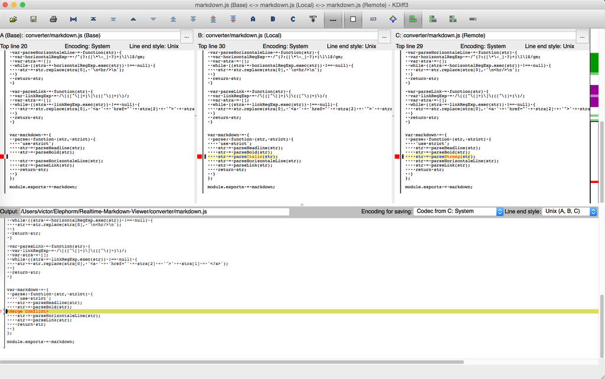

Les trois écrans correspondent respectivement à :

- L'état du fichier au niveau de l'ancêtre commun. Dans notre cas, l'ancêtre commun correspond au commit de merge de la branche `link` dans la branche `tp3`.
- L'état du fichier dans la branche où nous avons appelé le merge. Dans notre cas c'est la branche `italic`. À ce niveau là, nous avons l'appel à la fonction `parseItalic`.
- L'état du fichier dans la branche que nous mergeons. Dans notre cas, c'est la branche `tp3` où nous avons défini la fonction `parseStrong`.

L'écran du bas correspond à l'état que nous voulons enregistrer du fichier.

Ici, on y ajoute les modifications de B et C, soit par un copiez collez, soit plus simplement en utilisant les lettres B et C de la barre de menu.

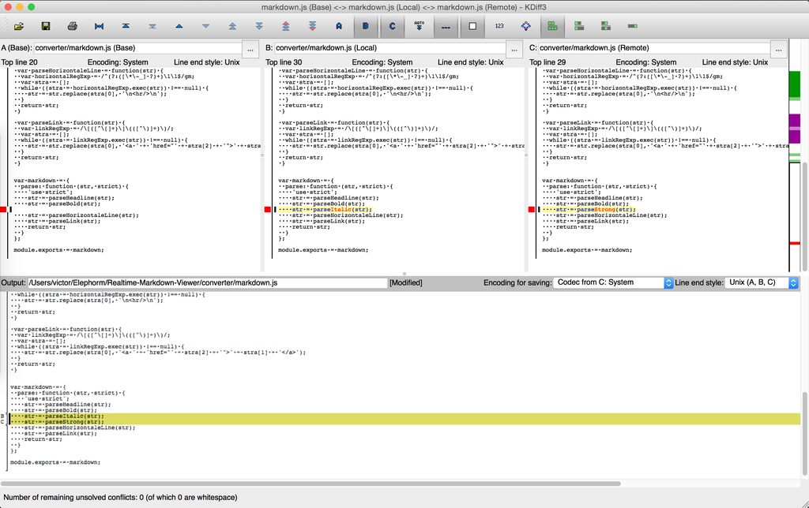

Une fois arrivé dans cet état là, vous pouvez sauvegarder et fermer le fichier.

La grosse différence avec un merge à la main est que le mergetool une fois fermé ajoute les fichiers à la staging area.

Pour s'en convaincre, il suffit de faire :

```bash
$ git status
On branch italic
All conflicts fixed but you are still merging.
  (use "git commit" to conclude merge)

Changes to be committed:

    modified:   converter/markdown.js
    modified:   converter/tests/features/bold.html
    new file:   converter/tests/features/strong.html
    new file:   converter/tests/features/strong.md

Untracked files:
  (use "git add <file>..." to include in what will be committed)

    converter/markdown.js.orig
```

Vous pouvez remarquer que le fichier `converter/markdown.js` est bien dans la staging area.

Autre chose intéressante est la création d'un fichier `converter/markdown.js.orig`. Celui ci est généré par le mergetool vous pouvez le supprimer directement via la commande `rm` ou par votre navigateur de fichier.

Il est néanmoins nécessaire de faire le commit de merge.

```bash
git commit
```

Vous pouvez vérifier que votre historique est le même :

```bash
$ git l
*   0f1cb4d (HEAD, italic) Merge branch 'tp3' into italic
|\
| * 4996867 (tp3) replace string with bold and add proper bold definition
* | aabeec2 add italic in parser
|/
*   d9058c6 Merge branch 'link' into tp3
|\
...
```

## 8. Intégrer les modifications de italic dans tp3

- Faites le merge de branch dans l'autre sens pour mettre à jour la branche `tp3` avec les modifications de `italic`.

```bash
$ git checkout tp3

$ git merge italic
Updating 4996867..0f1cb4d
Fast-forward
 converter/markdown.js                | 13 ++++++++++++-
 converter/tests/features/italic.html |  2 ++
 converter/tests/features/italic.md   |  2 ++
 3 files changed, 16 insertions(+), 1 deletion(-)
 create mode 100644 converter/tests/features/italic.html
 create mode 100644 converter/tests/features/italic.md
```

Vous pouvez remarquer que le merge a été un Fast-Forward, c'est à dire que les branches `tp3` et `italic` n'ont pas divergé, ce qui est logique puisque nous avons fait le merge dans l'autre sens.

- Supprimer la branche `italic` qui n'est plus utile maintenant.

```bash
$ git branch -d italic
```

- Vérifier l'historique :

```bash
$ git l
*   0f1cb4d (HEAD, tp3) Merge branch 'tp3' into italic
|\
| * 4996867 replace string with bold and add proper bold definition
* | aabeec2 add italic in parser
|/
*   d9058c6 Merge branch 'link' into tp3
|\
| * c3af8ef add link in parser
* | c8294f2 add bold in parser
|/
```